# Intro to ARIMA models

6 Apr 2023

## Big picture

Let’s imagine that we can describe our data as a combination of the mean trend (\(m_t\)) and error.

\[x_t = m_t + e_t\]

Fisheries biologists and ecologists often want to know \(m_t\). *In fact, that is often our main and sole goal*.

But let’s say we don’t care about \(m_t\). Our only goal is to predict \(x_{t+1}\).

How could we do this?

## Approach 1 which we will use in the rest of the course

1. We write a model for \(m_t\) and estimate that model from the data.
2. Once we have an estimated model for \(m_t\), we have an estimate of \(e_t\).
3. We can model that error (think AR and MA)
4. With 2 and 3, we can predict the future \(x_t\) from \(x_{t-1}\).

## Approach 2 Box-Jenkins

The Box-Jenkins approach (ARIMA models) is **totally** different.

1. Keep differencing the data to until you get a new transformed stationary time series \(\Delta^d x_t\)
2. Any stationary time series can be modeled as a ARMA process (Wold Decomposition). So now fit a ARMA model to \(\Delta^d x_t\)
3. Using the estimated ARMA, predict \(\Delta^d x_{t+1}\)
4. Using \(\Delta^d x_{t+1}\), \(x_t\), \(x_{t-1}\), \(x_{t-2}\), etc, you can compute \(x_{t+1}\)
5. That’s the prediction!

## What’s \(\Delta^d x_{t+1}\)

\[\Delta^1 x_t = x_t - x_{t-1}\] \[\Delta^2 x_t = \Delta^1 x_t - \Delta^1 x_{t-1}\] \[\Delta^3 x_t = \Delta^2 x_t - \Delta^2 x_{t-1}\]

## In Box-Jenkin’s approach \(m_t\) is gone

In this approach to predicting \(x_{t+1}\), we remove \(m_t\) from our data using differencing.

We don’t have to worry about a model for \(m_t\) because we have removed it!!

## How is that possible?

You can remove any wiggly trend with enough differencing.

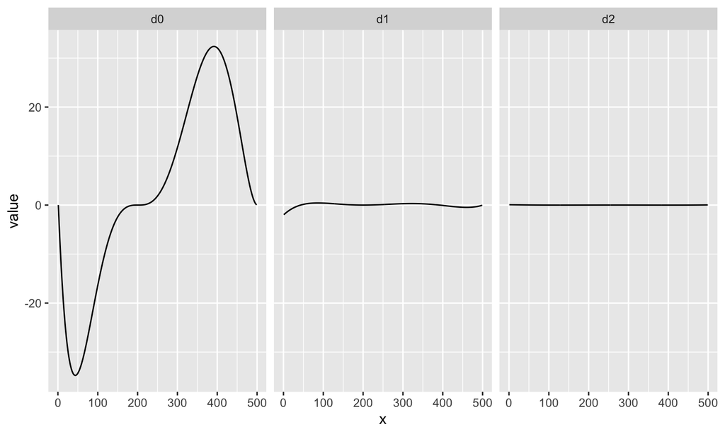

## A biological interpretation is hard for ARIMA models

The error structure of \(\Delta^d x_{t+1}\) is NOT the same as \(e_t\).

\[\Delta^d x_{t} = \phi_1\Delta^d x_{t-1} + \phi_2\Delta^d x_{t-2} + \dots + z_t\]

\(z_t\) is the error of the differences. And the \(\phi\) in the AR part are for the differences not the original \(x_t\).

But remember, the objective was to predict \(x_{t+1}\) not to fit a model with a biological interpretation.

## Box-Jenkins method for fitting ARIMA model

1. Make data stationary by differencing the data
2. Fit a ARMA model to the differenced data
3. Estimate the ARMA parameters
4. Predict \(x_{t+1}\)
5. Assess the residuals for problems

## Other approaches for non-stationary time series data

ARIMA models are one approach for fitting data that have underlying trends.

Other approaches

- Regression (we won’t cover this)
- Dynamic Linear Regression (we will cover this)
- Stochastic level models (we will do a lot of variants of this in class)
- ARMAX models: \(x_t = b x_{t-1} + \beta \text{covariates} + \text{error}\) (we will do some of this)